# NY Test Scores

Kara

9/23/2021

### Data Set: [Score Data](https://www.kaggle.com/nycopendata/high-schools)

### ML Question:

- Given demographic information on students can we predict the average Math SAT score?

### Business Metric:

- The school board could use this information to improve student testing performance. By identifying students who are more likely to score poorly, schools can preemptively provide these students with additional resources and hopefully improve testing outcomes.

### Prevalence:

Percentage of Low Scoring Tests (values below lower hinge of data)

| Low |
| --- |
| 26.00536 |

### Partitioned Data:

| Train | Test | Tune |
| --- | --- | --- |
| 262 | 55 | 56 |

### Train:

Trained machine learning model:

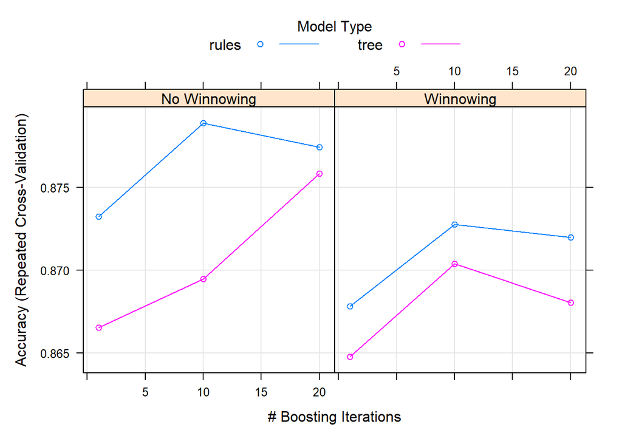

### Tune and evaluate

Testing the machine learning model against tune data set using a confusion matrix:

```
## Confusion Matrix and Statistics
##
##           Actual
## Prediction  0  1
##          0 36  5
##          1  6  9
##
##                Accuracy : 0.8036
##                  95% CI : (0.6757, 0.8977)
##     No Information Rate : 0.75
##     P-Value [Acc > NIR] : 0.2235
##
##                   Kappa : 0.4884
##
##  Mcnemar's Test P-Value : 1.0000
##
##             Sensitivity : 0.8571
##             Specificity : 0.6429
##          Pos Pred Value : 0.8780
##          Neg Pred Value : 0.6000
##              Prevalence : 0.7500
##          Detection Rate : 0.6429
##    Detection Prevalence : 0.7321
##       Balanced Accuracy : 0.7500
##
##        'Positive' Class : 0
##
```

Developing a new model:

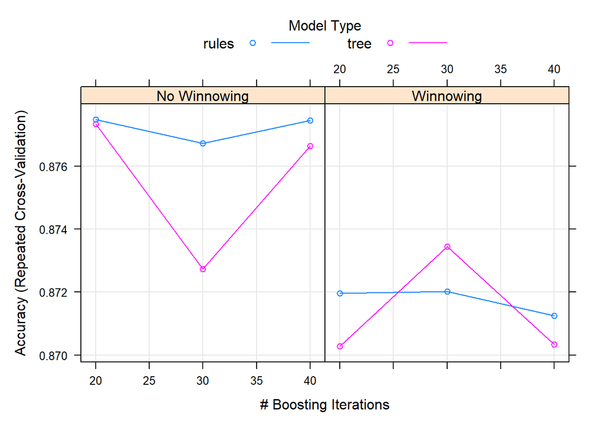

Evaluating the retrained model:

```
## Confusion Matrix and Statistics
##
##           Actual
## Prediction  0  1
##          0 36  5
##          1  6  9
##
##                Accuracy : 0.8036
##                  95% CI : (0.6757, 0.8977)
##     No Information Rate : 0.75
##     P-Value [Acc > NIR] : 0.2235
##
##                   Kappa : 0.4884
##
##  Mcnemar's Test P-Value : 1.0000
##
##             Sensitivity : 0.8571
##             Specificity : 0.6429
##          Pos Pred Value : 0.8780
##          Neg Pred Value : 0.6000
##              Prevalence : 0.7500
##          Detection Rate : 0.6429
##    Detection Prevalence : 0.7321
##       Balanced Accuracy : 0.7500
##
##        'Positive' Class : 0
##
```

### Testing

Evaluating the tuned model against test data set:

```
## Confusion Matrix and Statistics
##
##           Actual
## Prediction  0  1
##          0 38  2
##          1  4 11
##
##                Accuracy : 0.8909
##                  95% CI : (0.7775, 0.9589)
##     No Information Rate : 0.7636
##     P-Value [Acc > NIR] : 0.01428
##
##                   Kappa : 0.713
##
##  Mcnemar's Test P-Value : 0.68309
##
##             Sensitivity : 0.9048
##             Specificity : 0.8462
##          Pos Pred Value : 0.9500
##          Neg Pred Value : 0.7333
##              Prevalence : 0.7636
##          Detection Rate : 0.6909
##    Detection Prevalence : 0.7273
##       Balanced Accuracy : 0.8755
##
##        'Positive' Class : 0
##
```

#### Summary

##### Stats

- Surprisingly, tuning the data did not improve the accuracy of the model (remained constant at 80.36%). This could indicate that the default parameters of the model where already optimized for the two data sets.
- The model performed better on the test data set; 89.09% accuracy compared to 80.36%. A higher accuracy in the testing phase points to a more general model meaning it can capture patterns in data which it has not yet seen.
- Additionally, the accuracy of 89.09% is much higher than the prevalence of 74% (indicated by the 26% prevalence of the positive test case). This indicates that the model performs much better than a random guess.

##### Key Takeaways

- The key factors in determining the likelihood of a low score tend to be race and student enrollment. On the education board level, this information indicates the need to investigate the experiences of different demographics and how these experiences are affecting students’ learning. Additionally, because student enrollment is one of the most important factors, the school board could look into creating a more homogeneous distribution of students to ensure all students have similar education opportunities.

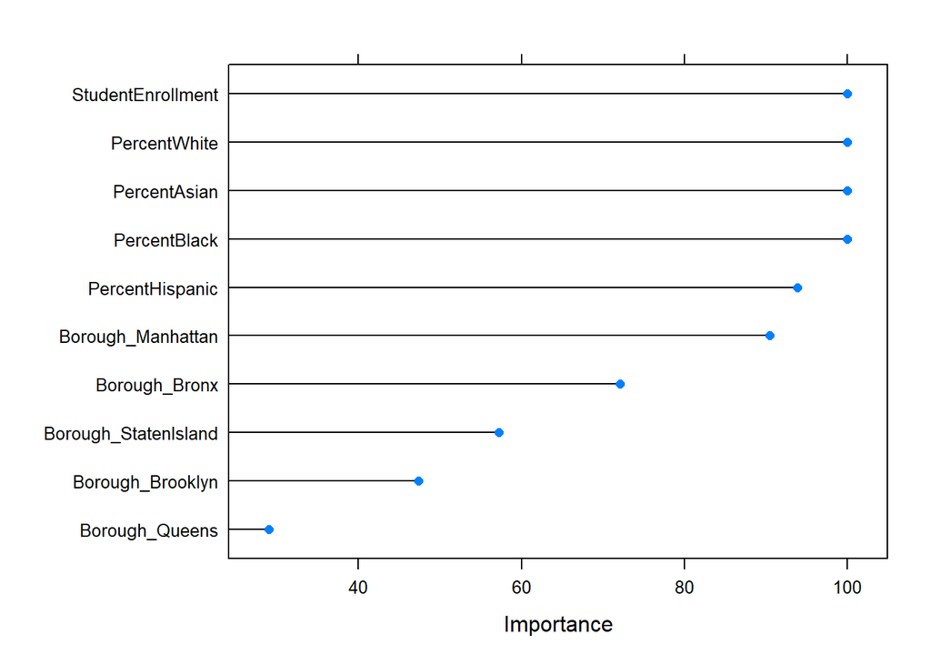

##### Concerns:

- While the model does indicate that race is an important factor in the model, it does not explain how or why race is impacting test scores. For example, race could impact test scores as a result of explicit racism within the school system or it could implicitly affect test score by reflecting the unequal access to test prep resources different races have due to their general socio-economic status.